# Statistics for Non-Detects

## 2. Core Concepts

### Detection limit vocabulary

| Term | Abbreviation | Definition |
| --- | --- | --- |
| Method Detection Limit | MDL | Lowest concentration distinguishable from blank at 99% confidence (EPA) |
| Reporting Limit | RL | Practical limit used in lab reports; often 3–5 × MDL |
| Limit of Detection | LOD | Generic term; use carefully — meaning varies by lab |
| Limit of Quantitation | LOQ | Level above which measurement is acceptably precise; typically 3–10 × MDL |
| Minimum Reporting Level | MRL | USGS term equivalent to RL |

In this tutorial we use **reporting limit (RL)** as the generic term for the censoring threshold. A measurement reported as `< RL` is a non-detect.

### Left censoring versus right censoring

In **survival analysis** (right censoring), we observe time up to some cutoff *c* and know only that T > c. Here, with **left censoring**, we observe that a concentration C is known only to satisfy C < RL. The Kaplan–Meier estimator handles both through a symmetric reversal: we flip the data, apply the standard KM algorithm, then flip the estimated CDF back.

### The fraction censored matters

The appropriate method depends heavily on what fraction of your data is below the reporting limit:

| Censoring fraction | Recommended approaches |
| --- | --- |
| < 15% | Any substitution method is likely acceptable; ROS preferred |
| 15–50% | ROS or MLE; avoid substitution |
| 50–80% | MLE or Kaplan–Meier; be cautious about distributional assumptions |
| > 80% | Kaplan–Meier only; summary statistics become unreliable |

**⚠️ Multiple detection limits**

A single dataset often contains measurements from different laboratories, different years, or different analytical methods — each with its own RL. This is called **multiply-censored data**. The Kaplan–Meier and ROS methods handle multiple RLs naturally. Simple substitution methods (½ MDL) cannot, because there is no single substitution value to use.

## 3. Packages and Data Setup

### Required packages

```r
# Core statistical methods for non-detects
library(NADA)       # cenros(), cenfit(), cencdf(), cenmle(), and hypothesis tests
library(NADA2)      # updated companion: cenperm2(), cen2means(), cenQQ()
library(survival)   # underlying Surv() infrastructure

# Data wrangling and visualization
library(dplyr)
library(tidyr)
library(ggplot2)
library(patchwork)  # combine ggplot panels
library(knitr)
library(kableExtra)
```

**💡 Installing NADA and NADA2**

`NADA` is on CRAN: `install.packages("NADA")`. `NADA2` may require the development version: `install.packages("NADA2")` or `remotes::install_github("SwampThingPaul/NADA2")`. Both implement Dennis Helsel’s methods from *Statistics for Censored Environmental Data* (Helsel 2012), the authoritative reference for this topic.

### Dataset 1: E. coli in recreational water (water quality)

We simulate monthly E. coli monitoring at three beach sites over two years. Units are CFU/100 mL. The state recreational water standard is 235 CFU/100 mL (single-sample). The laboratory reporting limit is 1 CFU/100 mL; samples below this are recorded as 0 in the raw data (a common field convention — **zero means non-detect, not absence**).

```r
set.seed(2024)

# Helper: simulate log-normal samples with left-censoring at RL
sim_censored <- function(n, meanlog, sdlog, rl) {
  true_vals <- rlnorm(n, meanlog = meanlog, sdlog = sdlog)
  detected  <- true_vals >= rl
  # Observed value: true value if detected, 0 if non-detect (field convention)
  obs       <- ifelse(detected, true_vals, 0)
  data.frame(
    true     = true_vals,
    observed = obs,
    censored = !detected,   # TRUE = non-detect
    rl       = rl
  )
}

# Three beach sites with different E. coli levels
set.seed(101)
ecoli <- bind_rows(
  sim_censored(24, meanlog = 3.2, sdlog = 1.1, rl = 1) |> mutate(site = "Beach A"),
  sim_censored(24, meanlog = 2.4, sdlog = 1.3, rl = 1) |> mutate(site = "Beach B"),
  sim_censored(24, meanlog = 4.1, sdlog = 0.9, rl = 1) |> mutate(site = "Beach C")
)

# Summarise censoring fractions
ecoli |>
  group_by(site) |>
  summarise(
    n          = n(),
    n_nd       = sum(censored),
    pct_nd     = round(100 * mean(censored), 1),
    min_det    = round(min(observed[!censored]), 1),
    max_det    = round(max(observed[!censored]), 1)
  ) |>
  kable(col.names = c("Site", "n", "Non-detects", "% ND", "Min detected", "Max detected"),
        caption = "E. coli dataset summary (CFU/100 mL; RL = 1 CFU/100 mL)")
```

E. coli dataset summary (CFU/100 mL; RL = 1 CFU/100 mL)

| Site | n | Non-detects | % ND | Min detected | Max detected |
| --- | --- | --- | --- | --- | --- |
| Beach A | 24 | 0 | 0.0 | 2.6 | 118.0 |
| Beach B | 24 | 2 | 8.3 | 1.3 | 51.8 |
| Beach C | 24 | 0 | 0.0 | 15.9 | 259.3 |

### Dataset 2: Total phosphorus in lake monitoring (water quality)

Total phosphorus (TP) in a temperate lake monitored quarterly at surface and deep stations. Units are µg/L. The RL is 5 µg/L; values below this are coded as 0. Elevated TP indicates eutrophication risk.

```r
set.seed(202)
tp <- bind_rows(
  sim_censored(30, meanlog = 2.1, sdlog = 0.8, rl = 5) |> mutate(depth = "Surface"),
  sim_censored(30, meanlog = 2.8, sdlog = 0.7, rl = 5) |> mutate(depth = "Deep")
)

tp |>
  group_by(depth) |>
  summarise(n = n(), n_nd = sum(censored),
            pct_nd = round(100 * mean(censored), 1)) |>
  kable(col.names = c("Depth", "n", "Non-detects", "% ND"),
        caption = "Total phosphorus dataset summary (µg/L; RL = 5 µg/L)")
```

Total phosphorus dataset summary (µg/L; RL = 5 µg/L)

| Depth | n | Non-detects | % ND |
| --- | --- | --- | --- |
| Deep | 30 | 1 | 3.3 |
| Surface | 30 | 7 | 23.3 |

### Dataset 3: Lead (Pb) in drinking water (water quality)

Lead sampling at 50 household taps under a Tier 2 monitoring plan. Units are µg/L. The EPA action level is 15 µg/L; the RL is 0.5 µg/L. Many modern homes with no lead service lines return non-detects.

```r
set.seed(303)
pb <- sim_censored(50, meanlog = 0.8, sdlog = 1.4, rl = 0.5) |>
  mutate(tap_id = paste0("Tap_", sprintf("%02d", 1:50)))

cat("Lead dataset: n =", nrow(pb),
    " | Non-detects:", sum(pb$censored),
    " (", round(100 * mean(pb$censored), 1), "%)\n")
```

```
## Lead dataset: n = 50  | Non-detects: 6  ( 12 %)
```

```r
cat("Detection range:", round(range(pb$observed[!pb$censored]), 2), "µg/L\n")
```

```
## Detection range: 0.56 56.5 µg/L
```

### Dataset 4: PM<sub>2.5</sub> daily concentrations (air quality)

Daily PM<sub>2.5</sub> at a rural background monitoring site over one year. Units are µg/m³. The RL is 2 µg/m³; days with very clean air register as 0. The 24-hour NAAQS is 35 µg/m³.

```r
set.seed(404)
# PM2.5: slight seasonal signal (higher in winter), mostly below RL in summer
pm25 <- data.frame(
  doy = 1:365
) |>
  mutate(
    # true seasonal log-mean: peaks in winter (day ~15, ~350), dips in summer
    meanlog   = 1.6 + 0.5 * cos(2 * pi * (doy - 15) / 365),
    true_conc = rlnorm(365, meanlog = meanlog, sdlog = 0.9),
    observed  = ifelse(true_conc >= 2, true_conc, 0),
    censored  = true_conc < 2,
    rl        = 2,
    season    = cut(doy, breaks = c(0, 79, 171, 263, 355, 366),
                    labels = c("Winter","Spring","Summer","Fall","Winter2"),
                    include.lowest = TRUE)
  ) |>
  mutate(season = recode(season, "Winter2" = "Winter"))

cat("PM2.5 dataset: n =", nrow(pm25),
    " | Non-detects:", sum(pm25$censored),
    " (", round(100 * mean(pm25$censored), 1), "%)\n")
```

```
## PM2.5 dataset: n = 365  | Non-detects: 59  ( 16.2 %)
```

## 4. Why Naïve Approaches Fail

Before introducing principled methods, let us see exactly how badly the common shortcuts perform using the lead dataset, where we have the true values available for comparison.

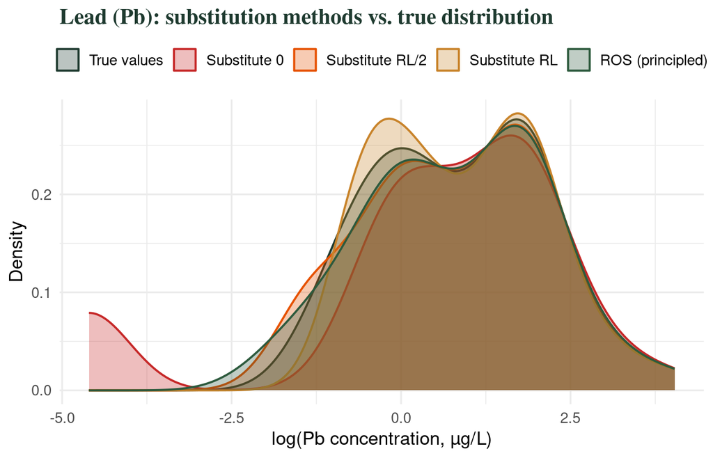

Distribution of lead concentrations by substitution method vs. the true distribution. Substituting zero collapses the lower tail entirely; substituting RL/2 is closer but systematically underestimates the lower tail. The ROS method (introduced in Section 6) closely recovers the true distribution.

```r
# Compute summary stats under each substitution strategy
sub_zero    <- pb$observed                          # non-detects treated as 0
sub_half    <- ifelse(pb$censored, pb$rl / 2, pb$observed)  # RL/2
sub_rl      <- ifelse(pb$censored, pb$rl,     pb$observed)  # substitute RL
true_vals   <- pb$true

# Use ROS (Section 6) for comparison — computed here, explained later
ros_fit     <- cenros(pb$observed, pb$censored)
sub_ros     <- ros_fit$modeled

methods_df <- bind_rows(
  data.frame(value = true_vals,  method = "True values"),
  data.frame(value = sub_zero,   method = "Substitute 0"),
  data.frame(value = sub_half,   method = "Substitute RL/2"),
  data.frame(value = sub_rl,     method = "Substitute RL"),
  data.frame(value = sub_ros,    method = "ROS (principled)")
) |>
  mutate(method = factor(method, levels = c("True values","Substitute 0",
                                            "Substitute RL/2","Substitute RL",
                                            "ROS (principled)")))

ggplot(methods_df, aes(x = log(value + 0.01), fill = method, colour = method)) +
  geom_density(alpha = 0.30, linewidth = 0.7) +
  scale_fill_manual(values  = c("#1e3a2f","#c62828","#e65100","#c8832a","#2d5a3d")) +
  scale_colour_manual(values = c("#1e3a2f","#c62828","#e65100","#c8832a","#2d5a3d")) +
  labs(x = "log(Pb concentration, µg/L)", y = "Density",
       title = "Lead (Pb): substitution methods vs. true distribution",
       fill = NULL, colour = NULL) +
  theme_minimal(base_size = 13) +
  theme(legend.position = "top",
        plot.title = element_text(family = "serif", face = "bold", colour = "#1e3a2f"))
```

```r
bias_table <- data.frame(
  Method   = c("True values", "Substitute 0", "Substitute RL/2",
                "Substitute RL", "ROS (principled)"),
  Mean     = round(c(mean(true_vals), mean(sub_zero), mean(sub_half),
                     mean(sub_rl),    mean(sub_ros)), 3),
  Median   = round(c(median(true_vals), median(sub_zero), median(sub_half),
                     median(sub_rl),    median(sub_ros)), 3),
  SD       = round(c(sd(true_vals), sd(sub_zero), sd(sub_half),
                     sd(sub_rl),    sd(sub_ros)), 3),
  P95      = round(c(quantile(true_vals, 0.95), quantile(sub_zero, 0.95),
                     quantile(sub_half, 0.95),  quantile(sub_rl, 0.95),
                     quantile(sub_ros, 0.95)), 3)
)

kable(bias_table,
      col.names = c("Method", "Mean (µg/L)", "Median (µg/L)", "SD", "95th pct"),
      caption   = "Summary statistics under different non-detect treatments. True values serve as the benchmark. ROS best recovers the true distribution statistics.") |>
  kable_styling(bootstrap_options = "striped") |>
  row_spec(1, bold = TRUE, color = "#1e3a2f") |>
  row_spec(5, bold = TRUE, color = "#2d5a3d")
```

Summary statistics under different non-detect treatments. True values serve as the benchmark. ROS best recovers the true distribution statistics.

| Method | Mean (µg/L) | Median (µg/L) | SD | 95th pct |
| --- | --- | --- | --- | --- |
| True values | 5.206 | 2.413 | 8.828 | 17.02 |
| Substitute 0 | 5.163 | 2.413 | 8.853 | 17.02 |
| Substitute RL/2 | 5.193 | 2.413 | 8.836 | 17.02 |
| Substitute RL | 5.223 | 2.413 | 8.819 | 17.02 |
| ROS (principled) | 5.194 | 2.413 | 8.835 | 17.02 |

**⚠️ The substitution bias is systematic, not random**

## 5. Kaplan–Meier for Left-Censored Data

The **Kaplan–Meier (KM) estimator** is the non-parametric workhorse for censored data. It makes no distributional assumption — it simply estimates the empirical CDF from the data as they are, treating non-detects as left-censored observations.

### The flip trick

Standard KM is designed for right-censoring (T > c). To handle left-censoring (C < RL), we **flip** the data: let x’ = max(x) − x and apply the right-censored KM estimator, then flip the estimated CDF back. The `NADA` package’s `cenfit()` does this automatically.

```r
# Kaplan-Meier for E. coli at Beach A
beach_a <- ecoli |> filter(site == "Beach A")

# cenfit(obs, censored_indicator)  — censored = TRUE means non-detect
km_a <- cenfit(beach_a$observed, beach_a$censored)

# Print summary statistics estimated from KM
print(km_a)
```

```
##        n    n.cen   median     mean       sd
## 24.00000  0.00000 19.83262 31.09971 28.21992
```

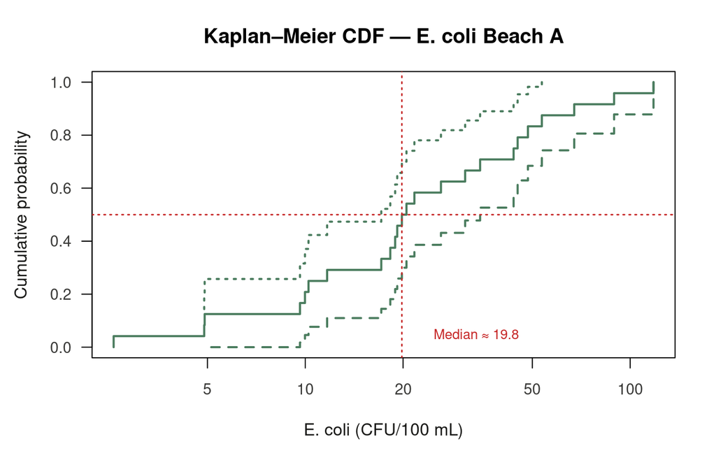

```r
# Plot the KM CDF
par(mar = c(5, 4.5, 3.5, 2), las = 1,
    col.axis = "#3a3a38", col.lab = "#1a1a18", cex.axis = 0.9)

plot(km_a,
     xlab = "E. coli (CFU/100 mL)",
     ylab = "Cumulative probability",
     main = "Kaplan–Meier CDF — E. coli Beach A",
     col  = "#4a7c5e", lwd = 2)

# Mark the standard
abline(v = 235, lty = 2, col = "#c8832a", lwd = 1.8)
text(250, 0.15, "235 CFU/100 mL\n(state standard)", col = "#c8832a",
     adj = 0, cex = 0.82)

# Mark the median
med_a <- median(km_a)
abline(h = 0.5, lty = 3, col = "#c62828", lwd = 1.4)
abline(v = med_a, lty = 3, col = "#c62828", lwd = 1.4)
text(med_a + 5, 0.05, paste0("Median ≈ ", round(med_a, 1)), col = "#c62828",
     adj = 0, cex = 0.80)
```

### Comparing three beach sites with KM

One of KM’s great strengths is comparing groups without any distributional assumption. We fit separate KM curves and then apply the non-parametric **log-rank-type test** (`cendiff()`) for equality of the distributions.

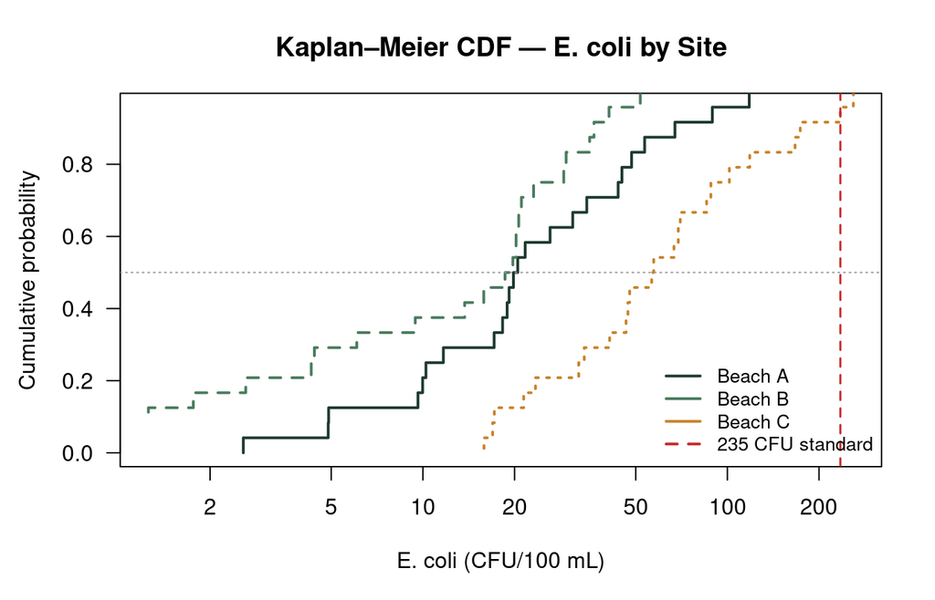

```r
km_all <- cenfit(ecoli$observed, ecoli$censored, groups = factor(ecoli$site))

par(mar = c(5, 4.5, 3.5, 2), las = 1)
plot(km_all,
     xlab = "E. coli (CFU/100 mL)",
     ylab = "Cumulative probability",
     main = "Kaplan–Meier CDF — E. coli by Site",
     col  = c("#1e3a2f", "#4a7c5e", "#c8832a"), lwd = 2)
abline(v = 235, lty = 2, col = "#c62828", lwd = 1.5)
abline(h = 0.50, lty = 3, col = "#999", lwd = 1)
legend("bottomright",
       legend = c("Beach A", "Beach B", "Beach C", "235 CFU standard"),
       col    = c("#1e3a2f", "#4a7c5e", "#c8832a", "#c62828"),
       lty    = c(1, 1, 1, 2), lwd = 2, bty = "n", cex = 0.85)
```

```r
# Non-parametric test for equality of distributions across sites
cendiff(ecoli$observed, ecoli$censored, groups = factor(ecoli$site))
```

```
##                             N Observed Expected (O-E)^2/E (O-E)^2/V
## factor(ecoli$site)=Beach A 24     11.0    13.29     0.381     0.895
## factor(ecoli$site)=Beach B 24      7.9    16.35     4.362    12.157
## factor(ecoli$site)=Beach C 24     17.5     6.82    16.771    28.499
##
##  Chisq= 30.2  on 2 degrees of freedom, p= 3e-07
```

**📌 Reading the output of cendiff()**

## 6. Regression on Order Statistics (ROS)

**Regression on Order Statistics (ROS)** is a semi-parametric method that estimates summary statistics by:

1. Ranking all observations together (detected and non-detected).
2. Computing expected normal (or log-normal) scores for the detected values.
3. Fitting a regression of detected values on their normal scores.
4. **Extrapolating** that regression line to predict what the non-detected values would have been, then substituting those modeled values.

The result is a **complete dataset** of modeled values that you can summarise or plot like ordinary data, as long as you remember that the non-detect slots have been imputed, not measured.

### Fitting ROS for phosphorus

```r
# ROS fit for total phosphorus — surface station
surf_tp <- tp |> filter(depth == "Surface")

ros_tp <- cenros(surf_tp$observed, surf_tp$censored)

# The returned object has $modeled — the full imputed dataset
cat("ROS-estimated mean TP (surface):", round(mean(ros_tp$modeled), 2), "µg/L\n")
```

```
## ROS-estimated mean TP (surface): 13.37 µg/L
```

```r
cat("ROS-estimated SD   TP (surface):", round(sd(ros_tp$modeled),   2), "µg/L\n")
```

```
## ROS-estimated SD   TP (surface): 14.41 µg/L
```

```r
cat("95th percentile (surface):       ", round(quantile(ros_tp$modeled, 0.95), 2), "µg/L\n")
```

```
## 95th percentile (surface):        35.77 µg/L
```

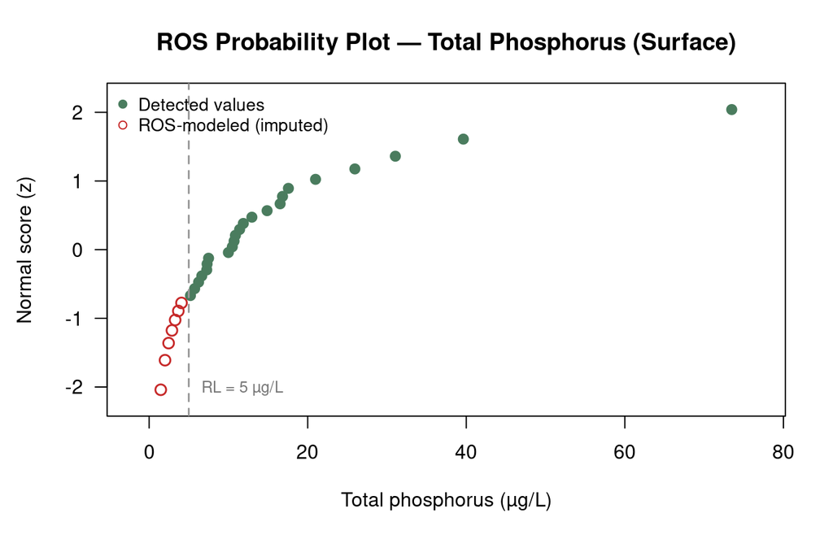

```r
par(mar = c(5, 4.5, 3.5, 2), las = 1)

# cenros() $modeled contains the full imputed dataset (NDs replaced by fitted values).
# We compute z-scores from Blom plotting positions on the complete modeled vector
# rather than using $zscores, which can contain NAs when many values are censored.
n_all      <- length(ros_tp$modeled)
pp         <- (rank(ros_tp$modeled) - 0.375) / (n_all + 0.25)
z_all      <- qnorm(pp)

is_det     <- !ros_tp$censored
x_detected <- ros_tp$modeled[is_det]
y_detected <- z_all[is_det]
x_modeled  <- ros_tp$modeled[!is_det]
y_modeled  <- z_all[!is_det]

# Compute safe axis limits (finite values only)
x_rng <- range(c(x_detected, x_modeled), finite = TRUE)
y_rng <- range(c(y_detected, y_modeled), finite = TRUE)
x_rng <- x_rng + c(-0.05, 0.05) * diff(x_rng)
y_rng <- y_rng + c(-0.05, 0.05) * diff(y_rng)

plot(x_detected, y_detected,
     pch = 19, col = "#4a7c5e", cex = 1.1,
     xlab = "Total phosphorus (µg/L)",
     ylab = "Normal score (z)",
     main = "ROS Probability Plot — Total Phosphorus (Surface)",
     xlim = x_rng, ylim = y_rng)

if (length(x_modeled) > 0)
  points(x_modeled, y_modeled, pch = 1, col = "#c62828", cex = 1.2, lwd = 1.5)

abline(v = surf_tp$rl[1], lty = 2, col = "#999", lwd = 1.5)
text(surf_tp$rl[1] + diff(x_rng) * 0.02, y_rng[1] + diff(y_rng) * 0.05,
     "RL = 5 µg/L", col = "#777", adj = 0, cex = 0.80)
legend("topleft",
       legend = c("Detected values", "ROS-modeled (imputed)"),
       pch    = c(19, 1),
       col    = c("#4a7c5e", "#c62828"),
       bty    = "n", cex = 0.88)
```

### Comparing surface and deep TP with ROS

```r
deep_tp  <- tp |> filter(depth == "Deep")
ros_deep <- cenros(deep_tp$observed, deep_tp$censored)

ros_summary <- data.frame(
  Depth    = c("Surface", "Deep"),
  n        = c(nrow(surf_tp), nrow(deep_tp)),
  pct_nd   = round(c(mean(surf_tp$censored), mean(deep_tp$censored)) * 100, 1),
  mean_ros = round(c(mean(ros_tp$modeled), mean(ros_deep$modeled)), 2),
  sd_ros   = round(c(sd(ros_tp$modeled),   sd(ros_deep$modeled)),   2),
  p95_ros  = round(c(quantile(ros_tp$modeled, 0.95),
                     quantile(ros_deep$modeled, 0.95)), 2)
)

kable(ros_summary,
      col.names = c("Depth", "n", "% ND", "Mean (µg/L)", "SD", "95th pct"),
      caption   = "ROS-estimated total phosphorus statistics by depth stratum.")
```

ROS-estimated total phosphorus statistics by depth stratum.

| Depth | n | % ND | Mean (µg/L) | SD | 95th pct |
| --- | --- | --- | --- | --- | --- |
| Surface | 30 | 23.3 | 13.37 | 14.41 | 35.77 |
| Deep | 30 | 3.3 | 24.32 | 18.08 | 59.84 |

## 7. Maximum Likelihood Estimation (MLE)

**Maximum Likelihood Estimation** fits a parametric distribution (usually log-normal) to the observed data, explicitly accounting for censoring in the likelihood function. Each detected value contributes the density f(x); each non-detect at RL contributes the probability F(RL) — the probability that the true value fell below the detection limit.

The log-likelihood for a log-normal distribution with n detected values and m non-detects is:

$$\ell(\mu, \sigma) = \sum_{i=1}^{n} \log
f(x_i;\, \mu, \sigma) \;+\; \sum_{j=1}^{m} \log F(RL_j;\, \mu,
\sigma)$$

Maximising this over (µ, σ) gives the MLE of the log-normal parameters, from which means, percentiles, and confidence intervals follow analytically.

### MLE for lead (Pb) in drinking water

```r
# cenmle() / survreg() require strictly positive values even for non-detects.
# Non-detects are coded as 0 in pb$observed; replace with the RL so that
# survreg sees a valid left-censored value (the true value is known to be < RL).
pb_obs_mle <- ifelse(pb$censored, pb$rl, pb$observed)

mle_pb <- cenmle(pb_obs_mle, pb$censored, dist = "lognormal")
print(mle_pb)
```

```
##         n     n.cen    median      mean        sd
## 50.000000  6.000000  2.290607  5.489231 11.954398
```

```r
# Extract mean and confidence interval
mle_stats <- summary(mle_pb)
cat("MLE log-normal fit for Pb:\n")
```

```
## MLE log-normal fit for Pb:
```

```r
cat("  Mean:     ", round(mean(mle_pb),  3), "µg/L\n")
```

```
##   Mean:      5.489 1.691 3.332 9.044 µg/L
```

```r
cat("  Median:   ", round(median(mle_pb),3), "µg/L\n")
```

```
##   Median:    2.291 µg/L
```

```r
cat("  95th pct: ", round(quantile(mle_pb, p = 0.95), 3), "µg/L\n")
```

```
##   95th pct:  20.155 µg/L
```

### Checking the distributional assumption with a Q–Q plot

MLE depends on the assumed distribution being correct. Always check with a Q–Q plot.

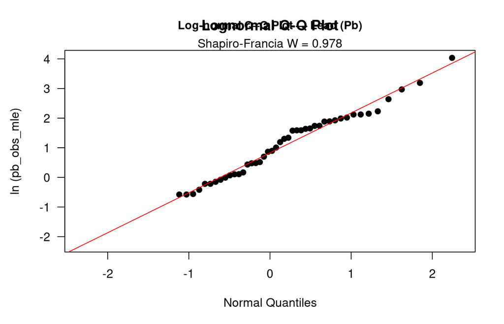

```r
par(mar = c(5, 4.5, 3.5, 2), las = 1)
cenQQ(pb_obs_mle, pb$censored)
title(main = "Log-normal Q–Q Plot — Lead (Pb)", cex.main = 0.95)
```

### When MLE is preferred over ROS

Method comparison for handling non-detects.

[output not shown]

## 8. Putting It Together: PM<sub>2.5</sub> Analysis

The PM<sub>2.5</sub> dataset combines seasonal structure, a meaningful detection limit, and a regulatory threshold. We walk through the complete analysis workflow.

### Step 1 — Visualise the raw data

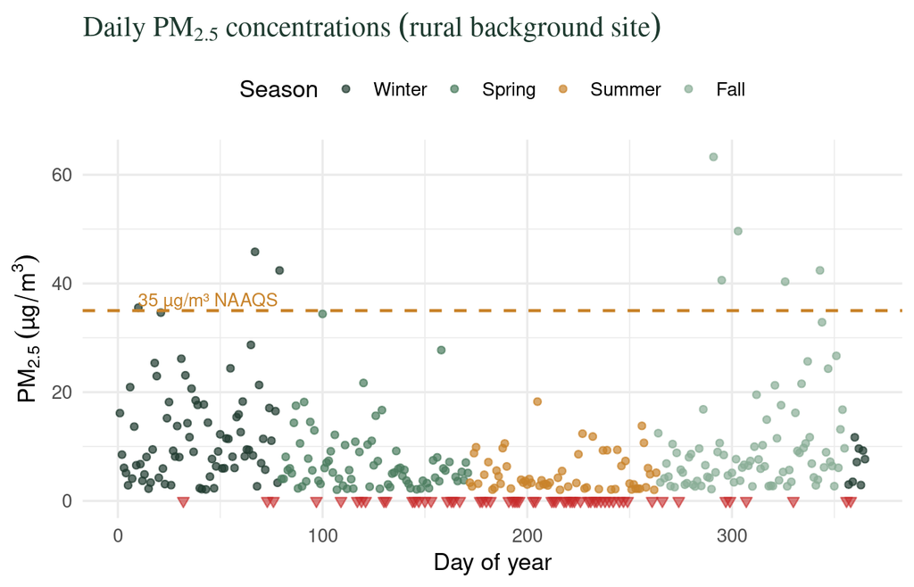

```r
pm25_plot <- pm25 |>
  mutate(season = factor(season, levels = c("Winter","Spring","Summer","Fall")))

ggplot(pm25_plot, aes(x = doy, y = observed)) +
  geom_point(data = filter(pm25_plot, !censored),
             aes(colour = season), size = 1.5, alpha = 0.7) +
  geom_point(data = filter(pm25_plot, censored),
             shape = 25, colour = "#c62828", fill = "#c62828",
             size = 1.8, alpha = 0.6) +
  geom_hline(yintercept = 35, linetype = "dashed", colour = "#c8832a", linewidth = 0.8) +
  annotate("text", x = 10, y = 37, label = "35 µg/m³ NAAQS", colour = "#c8832a",
           hjust = 0, size = 3.5) +
  scale_colour_manual(values = c("#1e3a2f","#4a7c5e","#c8832a","#8aad96"),
                      name = "Season") +
  labs(x = "Day of year", y = expression(PM[2.5]~(µg/m^3)),
       title = expression(Daily~PM[2.5]~concentrations~(rural~background~site))) +
  theme_minimal(base_size = 13) +
  theme(legend.position = "top",
        plot.title = element_text(family = "serif", face = "bold", colour = "#1e3a2f"))
```

### Step 2 — Fit KM and compute seasonal summary statistics

```r
# Compute KM-estimated mean and median by season
seasons <- c("Winter","Spring","Summer","Fall")

pm25_stats <- lapply(seasons, function(s) {
  d       <- filter(pm25, season == s)
  # Replace 0 (non-detect) with RL for cenmle; KM/cenfit handle 0s natively
  obs_mle <- ifelse(d$censored, d$rl, d$observed)
  km  <- cenfit(d$observed, d$censored)
  mle <- tryCatch(cenmle(obs_mle, d$censored, dist = "lognormal"),
                  error = function(e) NULL)
  data.frame(
    Season   = s,
    n        = nrow(d),
    pct_nd   = round(100 * mean(d$censored), 1),
    km_mean  = round(mean(km),   2),
    km_med   = round(median(km), 2),
    mle_mean = if (!is.null(mle)) round(mean(mle),   2) else NA
  )
}) |> bind_rows()

kable(pm25_stats,
      col.names = c("Season", "n", "% ND", "KM mean", "KM median", "MLE mean"),
      caption   = "PM2.5 seasonal summary statistics (µg/m³) from Kaplan–Meier and MLE fits.")
```

PM2.5 seasonal summary statistics (µg/m³) from Kaplan–Meier and MLE fits.

|  | Season | n | % ND | KM mean | KM median | MLE mean |
| --- | --- | --- | --- | --- | --- | --- |
| mean…1 | Winter | 89 | 5.6 | 11.25 | 8.51 | 11.64 |
| se…2 | Winter | 89 | 5.6 | 0.96 | 8.51 | 1.28 |
| 0.95LCL…3 | Winter | 89 | 5.6 | 9.36 | 8.51 | 9.47 |
| 0.95UCL…4 | Winter | 89 | 5.6 | 13.14 | 8.51 | 14.32 |
| mean…5 | Spring | 92 | 17.4 | 6.31 | 4.41 | 6.24 |
| se…6 | Spring | 92 | 17.4 | 0.59 | 4.41 | 0.65 |
| 0.95LCL…7 | Spring | 92 | 17.4 | 5.15 | 4.41 | 5.12 |
| 0.95UCL…8 | Spring | 92 | 17.4 | 7.47 | 4.41 | 7.61 |
| mean…9 | Summer | 92 | 34.8 | 4.06 | 2.47 | 3.80 |
| se…10 | Summer | 92 | 34.8 | 0.34 | 2.47 | 0.40 |
| 0.95LCL…11 | Summer | 92 | 34.8 | 3.40 | 2.47 | 3.11 |
| 0.95UCL…12 | Summer | 92 | 34.8 | 4.72 | 2.47 | 4.63 |
| mean…13 | Fall | 92 | 6.5 | 10.09 | 6.41 | 9.80 |
| se…14 | Fall | 92 | 6.5 | 1.15 | 6.41 | 1.10 |
| 0.95LCL…15 | Fall | 92 | 6.5 | 7.84 | 6.41 | 7.94 |
| 0.95UCL…16 | Fall | 92 | 6.5 | 12.35 | 6.41 | 12.09 |

### Step 3 — Compare seasons with a non-parametric test

```r
# Peto-Peto test across seasons
cendiff(pm25$observed, pm25$censored, groups = factor(pm25$season))
```

```
##                             N Observed Expected (O-E)^2/E (O-E)^2/V
## factor(pm25$season)=Winter 89     57.5     31.0     22.69     38.41
## factor(pm25$season)=Spring 92     41.0     48.6      1.18      2.37
## factor(pm25$season)=Summer 92     26.5     60.5     19.05     44.49
## factor(pm25$season)=Fall   92     53.1     38.1      5.89     10.63
##
##  Chisq= 72.3  on 3 degrees of freedom, p= 1e-15
```

### Step 4 — Exceedance probability

What fraction of days exceed the 35 µg/m³ NAAQS? Because detected values > 35 are always detects, we can compute this directly from the detected data.

```r
exceed_stats <- pm25 |>
  group_by(season) |>
  summarise(
    n_days       = n(),
    n_exceed     = sum(observed > 35, na.rm = TRUE),
    pct_exceed   = round(100 * mean(observed > 35, na.rm = TRUE), 1),
    annual_frac  = round(n_exceed / 365 * 100, 1)
  )

kable(exceed_stats,
      col.names = c("Season", "Days", "Exceedances", "% of season", "% of year"),
      caption   = "PM2.5 exceedances of the 35 µg/m³ 24-hour NAAQS by season.")
```

PM2.5 exceedances of the 35 µg/m³ 24-hour NAAQS by season.

| Season | Days | Exceedances | % of season | % of year |
| --- | --- | --- | --- | --- |
| Winter | 89 | 3 | 3.4 | 0.8 |
| Spring | 92 | 0 | 0.0 | 0.0 |
| Summer | 92 | 0 | 0.0 | 0.0 |
| Fall | 92 | 5 | 5.4 | 1.4 |

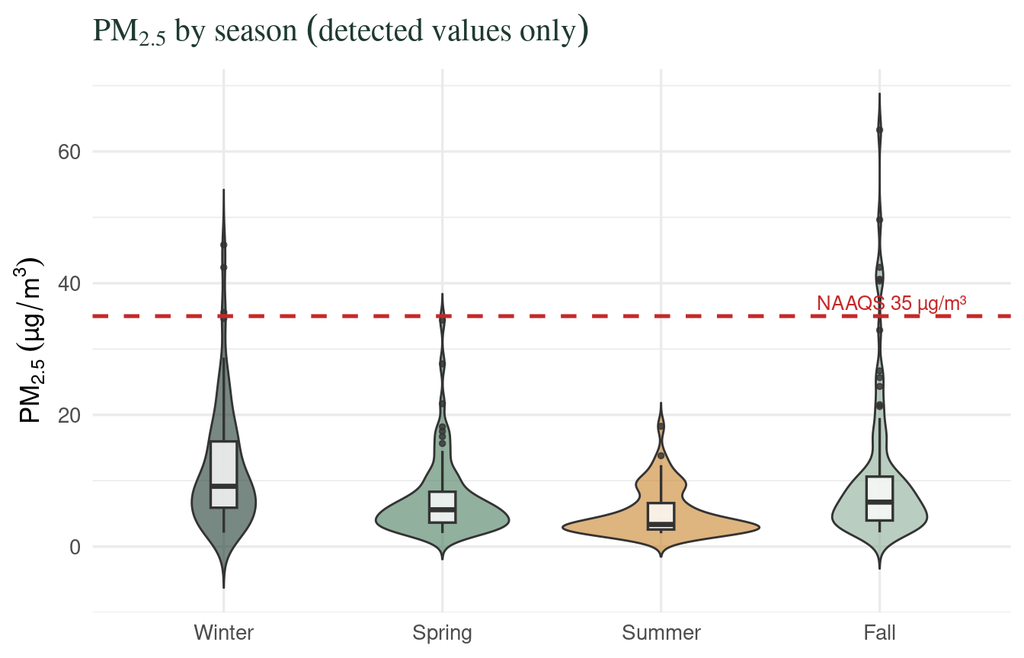

```r
pm25 |>
  filter(!censored) |>
  mutate(season = factor(season, levels = c("Winter","Spring","Summer","Fall"))) |>
  ggplot(aes(x = season, y = observed, fill = season)) +
  geom_violin(trim = FALSE, alpha = 0.6, linewidth = 0.5) +
  geom_boxplot(width = 0.12, outlier.size = 1, fill = "white", alpha = 0.8) +
  geom_hline(yintercept = 35, linetype = "dashed", colour = "#c62828", linewidth = 0.9) +
  annotate("text", x = 4.4, y = 37, label = "NAAQS 35 µg/m³",
           colour = "#c62828", hjust = 1, size = 3.4) +
  scale_fill_manual(values = c("#1e3a2f","#4a7c5e","#c8832a","#8aad96"), guide = "none") +
  labs(x = NULL, y = expression(PM[2.5]~(µg/m^3)),
       title = expression(PM[2.5]~by~season~(detected~values~only))) +
  theme_minimal(base_size = 13) +
  theme(plot.title = element_text(family = "serif", face = "bold", colour = "#1e3a2f"))
```

## 9. Hypothesis Tests for Censored Data

Standard t-tests and ANOVA are invalid when a substantial fraction of observations are non-detects. The `NADA2` package provides censored analogues.

### Two-sample test: Lead levels in older vs. newer homes

```r
# Simulate: older homes (pre-1978) have higher Pb than newer homes
set.seed(505)
pb2 <- bind_rows(
  sim_censored(30, meanlog = 1.5, sdlog = 1.2, rl = 0.5) |>
    mutate(era = "Pre-1978"),
  sim_censored(30, meanlog = 0.3, sdlog = 1.1, rl = 0.5) |>
    mutate(era = "Post-1978")
)

cat("Pre-1978 non-detects: ", sum(pb2$censored[pb2$era == "Pre-1978"]),
    "/30 (", round(100*mean(pb2$censored[pb2$era == "Pre-1978"]),1),"%)\n")
```

```
## Pre-1978 non-detects:  3 /30 ( 10 %)
```

```r
cat("Post-1978 non-detects:", sum(pb2$censored[pb2$era == "Post-1978"]),
    "/30 (", round(100*mean(pb2$censored[pb2$era == "Post-1978"]),1),"%)\n\n")
```

```
## Post-1978 non-detects: 7 /30 ( 23.3 %)
```

```r
# Censored Wilcoxon / Score test via cendiff()
cendiff(pb2$observed, pb2$censored, groups = factor(pb2$era))
```

```
##                            N Observed Expected (O-E)^2/E (O-E)^2/V
## factor(pb2$era)=Post-1978 30     10.3     18.9      3.87      15.5
## factor(pb2$era)=Pre-1978  30     19.2     10.7      6.83      15.5
##
##  Chisq= 15.5  on 1 degrees of freedom, p= 8e-05
```

### Pairwise comparisons for E. coli across sites

```r
# Permutation-based pairwise test (BH adjustment by default)
cenperm2(ecoli$observed, ecoli$censored, factor(ecoli$site))
```

```
##  Permutation test of mean CensData: ecoli$observed   by Factor: factor(ecoli$site)
##      9999 Permutations     alternative = two.sided
##   mean of Beach A = 31.1 to 31.1     mean of Beach B = 17.75 to 17.75
##      Mean (Beach A - Beach B) =  13.35 to 13.35       p = 0.3687 to 0.3687
##
```

### Correlation with censored data

Does phosphorus increase with turbidity? Standard Pearson r is biased when either variable contains non-detects. Use Kendall’s τ via `cenken()`.

```r
set.seed(606)
# Simulate turbidity (NTU) — positively correlated with TP, no non-detects
n_corr <- 40
turb_ntu <- rexp(n_corr, rate = 0.08) + 2

# TP correlated with turbidity, with non-detects
tp_corr <- 3 + 1.2 * turb_ntu + rnorm(n_corr, 0, 4)
obs_tp  <- pmax(tp_corr, 0)
nd_tp   <- tp_corr < 5
obs_tp[nd_tp] <- 0

# Kendall's tau for censored data
cenken(obs_tp, nd_tp, turb_ntu)
```

```
## Censored Kendall's Tau Regression:
## Slope     : 1.20433
## Intercept : 3.907174
## Tau       : 0.7717949
## p-value   : 2.420508e-12
```

**📌 Censored Kendall’s τ**

`cenken()` computes **Akritas–Murphy–LaValley (AML) Kendall’s τ**, a rank-based correlation coefficient that discards or downweights pairs where at least one member is a non-detect. The test is valid as long as the censoring fraction is below ~70–80%. The sign and magnitude of τ are interpreted exactly like ordinary Kendall’s τ: positive means the two variables tend to increase together.

## 10. Reporting Non-Detect Statistics

### What to always report

Reporting non-detects transparently is both a scientific and a regulatory obligation. Every summary table of censored data should include:

1. **Sample size** (total *n*)
2. **Number and fraction of non-detects** (e.g., “12/40, 30%”)
3. **Reporting limit(s)** (and whether multiple RLs were present)
4. **The method used** (KM, ROS, MLE, substitution) with a citation
5. **Estimates with uncertainty** (mean ± SE or 95% CI; percentiles)

### Complete example: Water quality summary table

```r
# Compute KM statistics for all four contaminants in a unified format
datasets <- list(
  "E. coli (Beach A, CFU/100 mL)" = list(obs = beach_a$observed,
                                           cen = beach_a$censored, rl = 1),
  "E. coli (Beach C, CFU/100 mL)" = list(obs = filter(ecoli, site=="Beach C")$observed,
                                           cen = filter(ecoli, site=="Beach C")$censored, rl = 1),
  "Total P – Surface (µg/L)"      = list(obs = surf_tp$observed,
                                           cen = surf_tp$censored, rl = 5),
  "Lead Pb (µg/L)"                = list(obs = pb$observed,
                                           cen = pb$censored, rl = 0.5),
  "PM2.5 – Winter (µg/m³)"        = list(obs = filter(pm25, season=="Winter")$observed,
                                           cen = filter(pm25, season=="Winter")$censored, rl = 2)
)

final_tbl <- lapply(names(datasets), function(nm) {
  d  <- datasets[[nm]]
  km <- cenfit(d$obs, d$cen)
  data.frame(
    Contaminant = nm,
    n           = length(d$obs),
    ND          = paste0(sum(d$cen), " (", round(100*mean(d$cen),0), "%)"),
    RL          = d$rl,
    KM_mean     = round(mean(km), 2),
    KM_median   = round(median(km), 2),
    Method      = "Kaplan–Meier"
  )
}) |> bind_rows()

kable(final_tbl,
      col.names = c("Contaminant (units)", "n", "Non-detects",
                    "RL", "Mean", "Median", "Method"),
      caption   = "Summary statistics for environmental monitoring data with non-detects. All estimates are from Kaplan–Meier using the NADA package (Helsel et al. 2020).") |>
  kable_styling(bootstrap_options = "striped")
```

Summary statistics for environmental monitoring data with non-detects. All estimates are from Kaplan–Meier using the NADA package (Helsel et al. 2020).

|  | Contaminant (units) | n | Non-detects | RL | Mean | Median | Method |
| --- | --- | --- | --- | --- | --- | --- | --- |
| mean…1 | E. coli (Beach A, CFU/100 mL) | 24 | 0 (0%) | 1.0 | 31.10 | 19.83 | Kaplan–Meier |
| se…2 | E. coli (Beach A, CFU/100 mL) | 24 | 0 (0%) | 1.0 | 5.76 | 19.83 | Kaplan–Meier |
| 0.95LCL…3 | E. coli (Beach A, CFU/100 mL) | 24 | 0 (0%) | 1.0 | 19.81 | 19.83 | Kaplan–Meier |
| 0.95UCL…4 | E. coli (Beach A, CFU/100 mL) | 24 | 0 (0%) | 1.0 | 42.39 | 19.83 | Kaplan–Meier |
| mean…5 | E. coli (Beach C, CFU/100 mL) | 24 | 0 (0%) | 1.0 | 78.80 | 56.41 | Kaplan–Meier |
| se…6 | E. coli (Beach C, CFU/100 mL) | 24 | 0 (0%) | 1.0 | 13.71 | 56.41 | Kaplan–Meier |
| 0.95LCL…7 | E. coli (Beach C, CFU/100 mL) | 24 | 0 (0%) | 1.0 | 51.94 | 56.41 | Kaplan–Meier |
| 0.95UCL…8 | E. coli (Beach C, CFU/100 mL) | 24 | 0 (0%) | 1.0 | 105.66 | 56.41 | Kaplan–Meier |
| mean…9 | Total P – Surface (µg/L) | 30 | 7 (23%) | 5.0 | 13.92 | 9.99 | Kaplan–Meier |
| se…10 | Total P – Surface (µg/L) | 30 | 7 (23%) | 5.0 | 2.57 | 9.99 | Kaplan–Meier |
| 0.95LCL…11 | Total P – Surface (µg/L) | 30 | 7 (23%) | 5.0 | 8.88 | 9.99 | Kaplan–Meier |
| 0.95UCL…12 | Total P – Surface (µg/L) | 30 | 7 (23%) | 5.0 | 18.96 | 9.99 | Kaplan–Meier |
| mean…13 | Lead Pb (µg/L) | 50 | 6 (12%) | 0.5 | 5.23 | 2.38 | Kaplan–Meier |
| se…14 | Lead Pb (µg/L) | 50 | 6 (12%) | 0.5 | 1.25 | 2.38 | Kaplan–Meier |
| 0.95LCL…15 | Lead Pb (µg/L) | 50 | 6 (12%) | 0.5 | 2.78 | 2.38 | Kaplan–Meier |
| 0.95UCL…16 | Lead Pb (µg/L) | 50 | 6 (12%) | 0.5 | 7.68 | 2.38 | Kaplan–Meier |
| mean…17 | PM2.5 – Winter (µg/m³) | 89 | 5 (6%) | 2.0 | 11.25 | 8.51 | Kaplan–Meier |
| se…18 | PM2.5 – Winter (µg/m³) | 89 | 5 (6%) | 2.0 | 0.96 | 8.51 | Kaplan–Meier |
| 0.95LCL…19 | PM2.5 – Winter (µg/m³) | 89 | 5 (6%) | 2.0 | 9.36 | 8.51 | Kaplan–Meier |
| 0.95UCL…20 | PM2.5 – Winter (µg/m³) | 89 | 5 (6%) | 2.0 | 13.14 | 8.51 | Kaplan–Meier |

### Common mistakes checklist

Mistake 1

“I replaced all non-detects with zero because the instrument read zero.”

**Correct approach:** Zero on a lab report means *below the reporting limit*, not truly zero. Use `cenfit()` or `cenros()`. Even 15% non-detects can meaningfully bias a mean when substituting zero.

Mistake 2

“I dropped all non-detects from the dataset to avoid the problem.”

**Correct approach:** Deleting non-detects removes the cleanest observations. Summary statistics will be biased high and you lose power. Every data point — detected or not — belongs in the analysis.

Mistake 3

“I used RL/2 substitution; my professor said that’s acceptable.”

**Correct approach:** RL/2 is acceptable only when the censoring fraction is below ~15% and the distribution is approximately log-normal. Above 15–20% non-detects, bias increases rapidly. Use ROS or MLE instead.

Mistake 4

“I ran a t-test on the data after RL/2 substitution.”

**Correct approach:** Substituted data are not ordinary continuous data — the t-test’s distributional assumptions are violated. Use `cendiff()` for two-group comparisons or `cenperm2()` for multiple groups.

#### 🔑 Key Takeaways

- **Non-detects are left-censored observations**, not zeros and not missing data. A result of “< RL” carries real information: the true value lies in [0, RL].
- **Substitution methods (0, RL/2, RL) are biased** whenever the censoring fraction exceeds ~15%. The bias is systematic and worsens with higher censoring.
- **Kaplan–Meier (`cenfit()`)** is non-parametric, handles multiple reporting limits, and is the safest choice when you cannot verify distributional assumptions. It is the baseline method.
- **ROS (`cenros()`)** produces a complete imputed dataset useful for visualization and regression; valid up to ~80% censoring when data are approximately log-normal.
- **MLE (`cenmle()`)** gives analytical confidence intervals and is most efficient when the distributional assumption is correct. Check with a censored Q–Q plot (`cenQQ()`).
- Use **`cendiff()`** for group comparisons and **`cenken()`** for censored correlations. Never apply standard t-tests or ANOVA directly to substituted data.
- Always report: *n*, number and fraction of non-detects, the reporting limit, and the method used — with a citation to Helsel (2012).

### What’s next?

- **Survival Analysis** — the right-censored twin of this problem; time-to-event methods with the same KM and Cox machinery
- **Time Series** — detecting trends in long-term monitoring data that also contain non-detects (Mann–Kendall with censoring)
- **Multiple Regression & GLMs** — building predictive models when the response variable contains non-detects

### Further reading

- Helsel, D.R. (2012). *Statistics for Censored Environmental Data Using Minitab and R*, 2nd ed. Wiley. — The authoritative reference; all methods here follow Helsel’s framework.
- Helsel, D.R., Hirsch, R.M., et al. (2020). *Statistical Methods in Water Resources*, USGS Techniques and Methods 4–A3. Freely available at pubs.usgs.gov.
- USEPA (2009). *Statistical Analysis of Groundwater Monitoring Data at RCRA Facilities: Unified Guidance.* EPA 530/R-09-007. — regulatory context for non-detect handling.